[figure not shown]

# Funções

### Funções

Para entender os cálculos no `R`, duas coisas devem ser lembradas:

- Tudo o que existe é um objeto;
- Tudo o que acontece é uma chamada de função.

*John Chambers*

### Funções

Para criar uma função no `R` será necessário seguir a seguinte sintaxe.

**Sintaxe**

```
name<-function(arguments){
    commands
}
```

### Funções

**Algumas considerações**

- O uso da instrução `function` é obrigatória para criar a função;
- Todas as funções `R` têm três partes:
  - `body`: O corpo, i.e., o código dentro da função;
  - `formals`: lista de argumentos da função;
  - `environment`: o "mapa" da localização das variáveis da função.

Quando você imprime uma função em R, mostra esses três componentes importantes. Se o ambiente não for exibido, significa que a função foi criada no ambiente global.

### Funções

```r
# Função para calcular a soma de dois números

soma <- function(a=1,b){
    resultado <- a+b
}

soma(2,5)

body(soma)  # corpo da função
formals(soma) # argumentos
environment(soma) # ambiente
```

[output not shown]

```
{
    resultado <- a + b
}
```

```
$a
[1] 1

$b
```

```
<environment: R_GlobalEnv>
```

### Funções

- Para explorar os métodos da função, pode ser usada a função `methods`.

```r
methods(generic.function = "plot")
```

```
 [1] plot.acf*           plot.data.frame*    plot.decomposed.ts*
 [4] plot.default        plot.dendrogram*    plot.density*
 [7] plot.ecdf           plot.factor*        plot.formula*
[10] plot.function       plot.hclust*        plot.histogram*
[13] plot.HoltWinters*   plot.isoreg*        plot.lm*
[16] plot.medpolish*     plot.mlm*           plot.ppr*
[19] plot.prcomp*        plot.princomp*      plot.profile.nls*
[22] plot.raster*        plot.spec*          plot.stepfun
[25] plot.stl*           plot.table*         plot.ts
[28] plot.tskernel*      plot.TukeyHSD*
see '?methods' for accessing help and source code
```

### Funções

```r
plot.default
```

```
function (x, y = NULL, type = "p", xlim = NULL, ylim = NULL,
    log = "", main = NULL, sub = NULL, xlab = NULL, ylab = NULL,
    ann = par("ann"), axes = TRUE, frame.plot = axes, panel.first = NULL,
    panel.last = NULL, asp = NA, xgap.axis = NA, ygap.axis = NA,
    ...)
{
    localAxis <- function(..., col, bg, pch, cex, lty, lwd) Axis(...)
    localBox <- function(..., col, bg, pch, cex, lty, lwd) box(...)
    localWindow <- function(..., col, bg, pch, cex, lty, lwd) plot.window(...)
    localTitle <- function(..., col, bg, pch, cex, lty, lwd) title(...)
    xlabel <- if (!missing(x))
        deparse1(substitute(x))
    ylabel <- if (!missing(y))
        deparse1(substitute(y))
    xy <- xy.coords(x, y, xlabel, ylabel, log)
    xlab <- if (is.null(xlab))
        xy$xlab
    else xlab
    ylab <- if (is.null(ylab))
        xy$ylab
    else ylab
    xlim <- if (is.null(xlim))
        range(xy$x[is.finite(xy$x)])
    else xlim
    ylim <- if (is.null(ylim))
        range(xy$y[is.finite(xy$y)])
    else ylim
    dev.hold()
    on.exit(dev.flush())
    plot.new()
    localWindow(xlim, ylim, log, asp, ...)
    panel.first
    plot.xy(xy, type, ...)
    panel.last
    if (axes) {
        localAxis(if (is.null(y))
            xy$x
        else x, side = 1, gap.axis = xgap.axis, ...)
        localAxis(if (is.null(y))
            x
        else y, side = 2, gap.axis = ygap.axis, ...)
    }
    if (frame.plot)
        localBox(...)
    if (ann)
        localTitle(main = main, sub = sub, xlab = xlab, ylab = ylab,
            ...)
    invisible()
}
```

### Funções

```r
plot.acf
```

```
Error in eval(expr, envir, enclos): objeto 'plot.acf' não encontrado
Traceback:
```

```r
getAnywhere(plot.acf)
```

```
A single object matching ‘plot.acf’ was found
It was found in the following places
  registered S3 method for plot from namespace stats
  namespace:stats
with value

function (x, ci = 0.95, type = "h", xlab = "Lag", ylab = NULL,
    ylim = NULL, main = NULL, ci.col = "blue", ci.type = c("white",
        "ma"), max.mfrow = 6, ask = Npgs > 1 && dev.interactive(),
    mar = if (nser > 2) c(3, 2, 2, 0.8) else par("mar"), oma = if (nser >
        2) c(1, 1.2, 1, 1) else par("oma"), mgp = if (nser >
        2) c(1.5, 0.6, 0) else par("mgp"), xpd = par("xpd"),
    cex.main = if (nser > 2) 1 else par("cex.main"), verbose = getOption("verbose"),
    ...)
{
    ci.type <- match.arg(ci.type)
    if ((nser <- ncol(x$lag)) < 1L)
        stop("x$lag must have at least 1 column")
    if (is.null(ylab))
        ylab <- switch(x$type, correlation = "ACF", covariance = "ACF (cov)",
            partial = "Partial ACF")
    snames <- x$snames %||% paste("Series ", if (nser == 1L)
        x$series
    else 1L:nser)
    with.ci <- ci > 0 && x$type != "covariance"
    with.ci.ma <- with.ci && ci.type == "ma" && x$type == "correlation"
    if (with.ci.ma && x$lag[1L, 1L, 1L] != 0L) {
        warning("can use ci.type=\"ma\" only if first lag is 0")
        with.ci.ma <- FALSE
    }
    clim0 <- if (with.ci)
        qnorm((1 + ci)/2)/sqrt(x$n.used)
    else c(0, 0)
    Npgs <- 1L
    nr <- nser
    if (nser > 1L) {
        sn.abbr <- if (nser > 2L)
            abbreviate(snames)
        else snames
        if (nser > max.mfrow) {
```

[output cut: 54 more lines]

```
            else paste(sn.abbr[i], "&", sn.abbr[j]), line = if (nser >
                2)
                1
            else 2)
        }
        if (Npgs > 1) {
            mtext(paste("[", I, ",", J, "]"), side = 1, line = -0.2,
                adj = 1, col = "dark gray", cex = 1, outer = TRUE)
        }
        dev.flush()
    }
    invisible()
}
<bytecode: 0x55938c004720>
<environment: namespace:stats>
```

### Funções

```r
methods(generic.function = "seq"); seq(1,10,2)
```

```
[1] seq.Date    seq.default seq.POSIXt
see '?methods' for accessing help and source code
```

1. 1

2. 3

3. 5

4. 7

5. 9

```r
getAnywhere(seq.default)
```

```
A single object matching ‘seq.default’ was found
It was found in the following places
  package:base
  registered S3 method for seq from namespace base
  namespace:base
with value

function (from = 1, to = 1, by = ((to - from)/(length.out - 1)),
    length.out = NULL, along.with = NULL, ...)
{
    is.logint <- function(.) (is.integer(.) || is.logical(.)) &&
        !is.object(.)
    if ((One <- nargs() == 1L) && !missing(from)) {
        lf <- length(from)
        return(if (mode(from) == "numeric" && lf == 1L) {
            if (!is.finite(from)) stop("'from' must be a finite number")
            1L:from
        } else if (lf) 1L:lf else integer())
    }
    if (!missing(along.with)) {
        length.out <- length(along.with)
        if (One)
            return(if (length.out) seq_len(length.out) else integer())
        intn1 <- is.integer(length.out)
    }
    else if (!missing(length.out)) {
        len <- length(length.out)
        if (!len)
            stop("argument 'length.out' must be of length 1")
        if (len > 1L) {
            warning("first element used of 'length.out' argument")
            length.out <- length.out[1L]
        }
        if (!(intn1 <- is.logint(length.out)))
            length.out <- as.numeric(ceiling(length.out))
    }
    chkDots(...)
    if (!missing(from) && length(from) != 1L)
        stop("'from' must be of length 1")
    if (!missing(to) && length(to) != 1L)
```

[output cut: 106 more lines]

```
            (naby <- is.na(by)) || ((from <- to - (length.out -
            1) * by) >= -.Machine$integer.max && from <= .Machine$integer.max))
        if (int && length.out > 2L && nby == 1L && !naby)
            cumsum(rep.int(c(as.integer(from), by), c(1L, length.out -
                1L)))
        else {
            if (intby && !(int || is.object(to)))
                storage.mode(by) <- "double"
            to - ((length.out - 1L):0L) * by
        }
    }
    else stop("too many arguments")
}
<bytecode: 0x55938850a280>
<environment: namespace:base>
```

### Funções

```r
runif
```

```
function (n, min = 0, max = 1)
.Call(C_runif, n, min, max)
```

```r
pryr::show_c_source(.Internal("runif"))
```

```
runif is implemented by do_random2 with op = 9

Please visit https://github.com/search?q=SEXP%20attribute_hidden%20do_random2+repo:wch/r-source&type=Code
```

Para a leitura de uma discussão muito boa sobre esse assunto sugiro o artigo de **Uwe Ligges** publicado no Vol. 6, p.43 da [R news](https://cran.r-project.org/doc/Rnews/Rnews_2006-4.pdf) em 2006.

Outra sugestão de leitura [Formas de ver o código fonte para funções do R.](https://stackoverflow.com/questions/19226816/how-can-i-view-the-source-code-for-a-function)

# Retornando valores de uma função

### `return` vs `print`

```r
# Função para calcular a soma de dois números

soma <- function(a,b){
    resultado <- a+b
    return(resultado) # Instrução return retorna apenas o valor e finaliza a função.
    print("fim")
}

soma(2,5)
```

7

```r
# Função para calcular a soma de dois números

soma <- function(a,b){
    resultado <- a+b
    print(resultado) # Instrução print imprime na tela e retornar o valor impresso.
    print("fim")
}

soma(2,5)
```

```
[1] 7
[1] "fim"
```

### `return` vs `print`

```r
# Retornando com print

cenario.1 <- function(x) {
  f<-1
  for (i in 1:x) {
    f <- f + i
    print(f)
  }
  print(f)
}

cenario.1(2)
```

```
[1] 2
[1] 4
[1] 4
```

### `return` vs `print`

```r
# Retornando com print
cenario.2 <- function(x) {
    f<-1
    for(i in 1:x){
        f <- f + i
        print(f)
    }
    return(f)
}

cenario.2(2)
```

```
[1] 2
[1] 4
```

4

### `return` vs `print`

```r
cenario.3 <- function(x){
    f<-1
    for(i in 1:x){
        f <- f + i
        return(f)
    }
    print(f)
}

cenario.3(2)
```

2

### `return` vs `print`

```r
quadratic.root <- function(a, b, c) {
    if(a == 0){
        stop("O parâmetro 'a' deve ser diferente de zero.")
    }
    d <- 2 * a
    delta <- b^2 - 4 * a * c
    if (delta < 0) {
        warning("Discriminante não é positivo. Não existem raizes reais.")
        r <- c(NA, NA)
    } else{
        r <- (-b + c(-1, 1) * sqrt(delta))/d
    }
    x <- -b/d
    y <- a * x^2 + b * x + c
    L <- list(x = x, y = y, r = r)
    class(L) <- "quadratica"
    return(L)
}
```

### `return` vs `print`

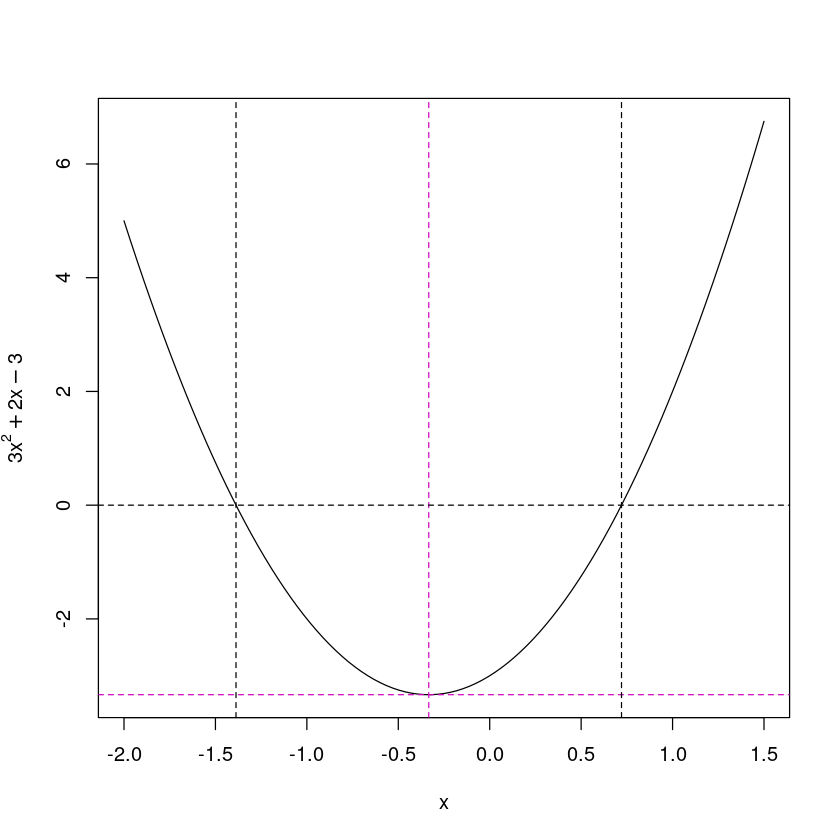

```r
a <- quadratic.root(3, 2, -3)

plot.quadratica <- function(a){
    abline(v = a$x, h = a$y, col = 6, lty = 2)
    abline(v = a$r, h = 0, col = 1, lty = 2)
}

curve(3 * x^2 + 2 * x - 3, -2, 1.5,ylab=bquote(3 * x^2 + 2*x - 3)); plot(a)
```

### Fixando argumentos

```r
produto <- function(x=1, y = 2){
    return(x*y)
}

produto(y=5)
```

5

### Fixando argumentos

```r
h <- function(x = 1, y = x * 2, z = a + b){
    a <- 10
    b <- 100
    c(x, y, z)
}

h()
```

1. 1

2. 2

3. 110

### Qual o resultado do seguinte código?

```r
# Exercício

x <- 10
f1 <- function(x){
    function(){
        x + 5
    }
}

f1(1)()
```

6

### Qual o resultado do seguinte código?

```r
# Exercício

f <- function(x){
    f <- function(x){
        f <- function(){
            x^2
        }
        f() + 1
    }
    f(x) * 2
}

f(10)
```

202

# Outro tipo de funções

### Funções “infixas” (infix functions)

No `R`, a maioria das funções são "prefixadas", isso significa que o nome da função vem antes dos argumentos. Existem outro tipo de funções cujo nome vem entre os argumentos, da forma `a fun b`. Esse tipo de funções são chamadas de *infixadas* (tradução livre de *infix function*).

**Sintaxe**

```
`%function_name%` <- function(variable1,variable2) {
  do_some_stuffs(variable1,variable2)
}

# chamando a função
variable1 %function_name% variable2
```

### Funções “infixas” (infix functions)

### Algumas considerações

- No `R`, os acentos graves (*backticks*) são usados para denotar um nome especial. Na verdade, você pode colocar qualquer caractere entre eles (até mesmo emojis, isso mesmo, emojis!)
- Os dois simbolos `%` ao redor do nome da função são necessários se você deseja criar suas próprias funções *infixas*. Como `%` é um caractere especial, você precisa usá-lo dentro de acentos graves. Observe que as funções *infixas* básicas não precisam do sinal de porcentagem, mas o gerado pelo usuário precisa.

### Funções “infixas” (infix functions)

```r
# Esta função é equivalente a 1:10
`:`(1,10)

# Esta função é equivalente a 2+3
`+`(2,3)
```

1. 1

2. 2

3. 3

4. 4

5. 5

6. 6

7. 7

8. 8

9. 9

10. 10

5

```r
# Esta função é equivalente a x<-y = 50
`<-`(x, `=`(y, 50)); x; y
```

50

50

```r
`for`(i, 1:2, print(i))
```

```
[1] 1
[1] 2
```

### Funções “infixas” (infix functions)

```r
`%maior%` <- function(a, b){
    if(a > b){
        print(a)
    } else if(b > a){
        print(b)
    } else{
        print("equal")
    }
}


8 %maior% 30
```

```
[1] 30
```

### Funções “infixas” (infix functions)

```r
`%uma_pausa%` <- function(a,b) {
  print(a);Sys.sleep(10);print(b)
  }

Sys.time() %uma_pausa% Sys.time()
```

```
[1] "2021-08-10 10:18:29 -03"
[1] "2021-08-10 10:18:39 -03"
```

[figure not shown]

### Funções “infixas” (infix functions)

Podemos substituir as funções padrão de forma conveniente (isso se quiser deixar alguém louco):

```r
`+` <- function(a,b){
    a**b
}

2+20
```

1048576

```r
# Restaurando a ordem natural das coisas

`+` <- .Primitive("+")
```

### Funções “infixas” (infix functions)

```r
`<-` <- .Primitive("*")
6 <- 3
```

18

```r
# Restaurando a ordem natural das coisas

`<-` = .Primitive("<-")
```

### Funções “infixas” (infix functions)

```r
`:` <- .Primitive("-")

`for`(i, 1:2, print(i))
```

```
[1] -1
```

```r
# Restaurando a ordem natural das coisas

`:` <- .Primitive(":")
```

### Funções “infixas” (infix functions)

```r
suppressMessages(if(!require(dplyr)) install.packages("dplyr", repos = "http://cran.us.r-project.org"))

head(starwars)
```

A tibble: 6 × 14

| name <chr> | height <int> | mass <dbl> | hair_color <chr> | skin_color <chr> | eye_color <chr> | birth_year <dbl> | sex <chr> | gender <chr> | homeworld <chr> | species <chr> | films <list> | vehicles <list> | starships <list> |
| --- | --- | --- | --- | --- | --- | --- | --- | --- | --- | --- | --- | --- | --- |
| Luke Skywalker | 172 | 77 | blond | fair | blue | 19.0 | male | masculine | Tatooine | Human | The Empire Strikes Back, Revenge of the Sith , Return of the Jedi , A New Hope , The Force Awakens | Snowspeeder , Imperial Speeder Bike | X-wing , Imperial shuttle |
| C-3PO | 167 | 75 | NA | gold | yellow | 112.0 | none | masculine | Tatooine | Droid | The Empire Strikes Back, Attack of the Clones , The Phantom Menace , Revenge of the Sith , Return of the Jedi , A New Hope |  |  |
| R2-D2 | 96 | 32 | NA | white, blue | red | 33.0 | none | masculine | Naboo | Droid | The Empire Strikes Back, Attack of the Clones , The Phantom Menace , Revenge of the Sith , Return of the Jedi , A New Hope , The Force Awakens |  |  |
| Darth Vader | 202 | 136 | none | white | yellow | 41.9 | male | masculine | Tatooine | Human | The Empire Strikes Back, Revenge of the Sith , Return of the Jedi , A New Hope |  | TIE Advanced x1 |
| Leia Organa | 150 | 49 | brown | light | brown | 19.0 | female | feminine | Alderaan | Human | The Empire Strikes Back, Revenge of the Sith , Return of the Jedi , A New Hope , The Force Awakens | Imperial Speeder Bike |  |
| Owen Lars | 178 | 120 | brown, grey | light | blue | 52.0 | male | masculine | Tatooine | Human | Attack of the Clones, Revenge of the Sith , A New Hope |  |  |

### Funções “infixas” (infix functions)

```r
`%😃%` <- dplyr::filter

# equivalente a dplyr::filter(starwars,species=="Human" & height==172)

starwars %😃% (species=="Human" & height==172)
```

A tibble: 1 × 14

| name <chr> | height <int> | mass <dbl> | hair_color <chr> | skin_color <chr> | eye_color <chr> | birth_year <dbl> | sex <chr> | gender <chr> | homeworld <chr> | species <chr> | films <list> | vehicles <list> | starships <list> |
| --- | --- | --- | --- | --- | --- | --- | --- | --- | --- | --- | --- | --- | --- |
| Luke Skywalker | 172 | 77 | blond | fair | blue | 19 | male | masculine | Tatooine | Human | The Empire Strikes Back, Revenge of the Sith , Return of the Jedi , A New Hope , The Force Awakens | Snowspeeder , Imperial Speeder Bike | X-wing , Imperial shuttle |

```r
# Avalia se uma certa cor de olhos foi observada na amostra

"red" %in% starwars$eye_color
```

TRUE

Uma listagem com todas as funções *infixas* do `R` está disponível [aqui.](https://gist.github.com/hrbrmstr/58b827dea95a7adf0f0e751b44b75b0c#file-infix_functions-r)

# Operadores pipe

### Operadores pipe

Os operadores *pipe* são operadores que permitem encadear estruturas de dados funções de forma elegante e eficiente.

A ideia do operador é bem simples: usar o valor resultante da expressão do lado esquerdo como primeiro argumento da função do lado direito.

Alguns deles são: `%>%`, `%<>%`, `%$%` e `%T>%`. Todos eles disponíveis no pacote `magrittr`.

Na versão 4.1 do `R` trouxe a inclusão de um operador pipe nativo, o `|>`.

### Operadores pipe

Considere os seguintes exemplos:

```r
x <- c(1, 2, 3, 4)
sqrt(sum(x))
```

3.16227766016838

```r
suppressMessages(if(!require(magrittr)) install.packages("magrittr", repos = "http://cran.us.r-project.org"))

x%>%sum%>%sqrt
```

[output not shown]

```r
round(mean(sum(1:10)/3), digits = 1)
```

18.3

```r
((1:10)/3)%>%sum%>%mean%>%round(digits=1)
```

18.3

### Operadores pipe

```r
# dplyr::filter(starwars,species=="Human" & height==172)

starwars |>
    filter(species=="Human" & height==172)
```

A tibble: 1 × 14

| name <chr> | height <int> | mass <dbl> | hair_color <chr> | skin_color <chr> | eye_color <chr> | birth_year <dbl> | sex <chr> | gender <chr> | homeworld <chr> | species <chr> | films <list> | vehicles <list> | starships <list> |
| --- | --- | --- | --- | --- | --- | --- | --- | --- | --- | --- | --- | --- | --- |
| Luke Skywalker | 172 | 77 | blond | fair | blue | 19 | male | masculine | Tatooine | Human | The Empire Strikes Back, Revenge of the Sith , Return of the Jedi , A New Hope , The Force Awakens | Snowspeeder , Imperial Speeder Bike | X-wing , Imperial shuttle |

# Funções anônimas

### Funções anônimas

Também conhecidas como funções *lambdas*, são funções que não precisam receber um nome, ou seja, podem ser utilizadas pelo programa na hora de sua criação.

A nova função anônima é declarada com uma barra invertida `\` (*backslash*) seguida por todos os argumentos entre parênteses e o código

```r
suppressMessages(if(!require(purrr)) install.packages("purrr", repos = "http://cran.us.r-project.org"))
```

```r
# Sem função anônima
incremento <- function(x){
    x + 1
}

purrr::map(1:5, incremento)
```

[output not shown]

### Funções anônimas

```r
# A notação nova permite qualquer nome
purrr::map(1:5, \(x) x + 1)
```

[output not shown]

```r
(function(x) x + 1)(1:5)
```

[output not shown]

# Exercício

Sejam $U_1,U_2,\ldots,U_n$ variáveis aleatórias independentes e identicamente distribuidas com distribuição uniforme em $(0,1)$. Considere $Z=\sum_{i=1}^{12}U_i-6$ e $Y=\cos(2\pi U_1)\sqrt{-2\log U_2}$.

1. Compare as distribuições empíricas de $Z$ e $Y$. O que você poderia dizer a respeito das distribuições?
2. Avalie as medidas de tendência central e dispersão da variável $X=\frac{Z}{Y}$. Realize uma análise detalhada da distribuição de $X$.

**Dica**: Para geração dos valores uniformes podem usar a função `runif`.

```r
sessioninfo::session_info()$platform
```

```
 setting  value
 version  R version 4.1.0 (2021-05-18)
 os       Ubuntu 20.04.2 LTS
 system   x86_64, linux-gnu
 ui       X11
 language pt_BR:pt:en
 collate  en_GB.utf8
 ctype    en_GB.utf8
 tz       America/Sao_Paulo
 date     2021-08-10
```

```r
Sys.time()
```

```
[1] "2021-08-10 10:44:53 -03"
```